# Python libraries for Machine Learning

## Python libraries for Machine Learning

https://www.geeksforgeeks.org/best-python-libraries-for-machine-learning/

NumPy is a very popular python library for large multi-dimensional array and matrix processing, with the help of a large collection of high-level mathematical functions. It is very useful for fundamental scientific computations in Machine Learning. It is particularly useful for linear algebra, Fourier transform, and random number capabilities. High-end libraries like TensorFlow uses NumPy internally for manipulation of Tensors.

```python
# Python program using NumPy
# for some basic mathematical
# operations

import numpy as np

# Creating two arrays of rank 2
x = np.array([[1, 2], [3, 4]])
y = np.array([[5, 6], [7, 8]])

# Creating two arrays of rank 1
v = np.array([9, 10])
w = np.array([11, 12])

# Inner product of vectors
print(np.dot(v, w), "\n")

# Matrix and Vector product
print(np.dot(x, v), "\n")

# Matrix and matrix product
print(np.dot(x, y))
```

```
219

[29 67]

[[19 22]
 [43 50]]
```

SciPy is a very popular library among Machine Learning enthusiasts as it contains different modules for optimization, linear algebra, integration and statistics. There is a difference between the SciPy library and the SciPy stack. The SciPy is one of the core packages that make up the SciPy stack. SciPy is also very useful for image manipulation.

```
uint8 (1199, 1200, 3)
uint8 (1199, 1200, 3)
```

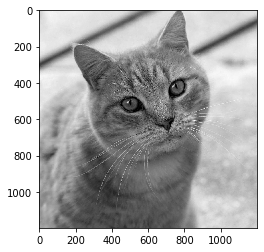

```python
import imageio
import numpy as np
import matplotlib
import matplotlib.pyplot as plt
%matplotlib inline

# Read a JPEG image into a numpy array
color = imageio.imread('cat.jpg')
print(color.dtype, color.shape)

def rgb2gray(rgb):
    img_bw = np.zeros((rgb.shape[0], rgb.shape[1], 3), dtype=np.uint8)
    r, g, b = rgb[:,:,0], rgb[:,:,1], rgb[:,:,2]
    gray = r * 0.2126 + g * 0.7152 + b * 0.0722
    img_bw[:,:,0] = gray
    img_bw[:,:,1] = gray
    img_bw[:,:,2] = gray
    return img_bw

grayImage = rgb2gray(color)
print(grayImage.dtype, grayImage.shape)

imageio.imwrite('cat_gray.jpg', grayImage)
im_new = imageio.imread('cat_gray.jpg')
plt.imshow(im_new)
```

OpenCV (Open Source Computer Vision Library) is an open source computer vision and machine learning software library. OpenCV was built to provide a common infrastructure for computer vision applications and to accelerate the use of machine perception in the commercial products. Being a BSD-licensed product, OpenCV makes it easy for businesses to utilize and modify the code.

```python
import numpy as np
import cv2
```

```python
img = cv2.imread('messi5.jpg',1)
```

```python
cv2.namedWindow('image', cv2.WINDOW_NORMAL)
cv2.imshow('image',img)
cv2.waitKey(0)
cv2.destroyAllWindows()
```

```python
print(img.dtype, img.shape)
cv2.imwrite('messigray.png',img)
```

```
uint8 (342, 548, 3)
```

```
True
```

[figure not shown]

```python
from matplotlib import pyplot as plt
%matplotlib inline

img = cv2.imread('messi5.jpg',0)
plt.imshow(img, cmap = 'gray', interpolation = 'bicubic')
plt.xticks([]), plt.yticks([])  # to hide tick values on X and Y axis
plt.show()
```

[figure not shown]

```python
img_inv = cv2.bitwise_not(img)
plt.imshow(img_inv, cmap = 'gray')
plt.xticks([]), plt.yticks([])  # to hide tick values on X and Y axis
plt.show()
```

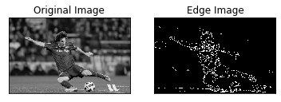

```python
img = cv2.imread('messi5.jpg',0)
edges = cv2.Canny(img,100,200)

plt.subplot(121),plt.imshow(img,cmap = 'gray')
plt.title('Original Image'), plt.xticks([]), plt.yticks([])
plt.subplot(122),plt.imshow(edges,cmap = 'gray')
plt.title('Edge Image'), plt.xticks([]), plt.yticks([])

plt.show()
```

Skikit-learn is one of the most popular ML libraries for classical ML algorithms. It is built on top of two basic Python libraries, viz., NumPy and SciPy. Scikit-learn supports most of the supervised and unsupervised learning algorithms. Scikit-learn can also be used for data-mining and data-analysis, which makes it a great tool who is starting out with ML.

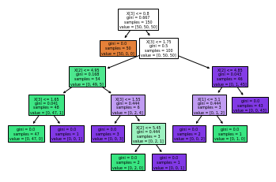

```
              precision    recall  f1-score   support

           0       1.00      1.00      1.00        50
           1       1.00      1.00      1.00        50
           2       1.00      1.00      1.00        50

    accuracy                           1.00       150
   macro avg       1.00      1.00      1.00       150
weighted avg       1.00      1.00      1.00       150

[[50  0  0]
 [ 0 50  0]
 [ 0  0 50]]
```

```python
# Python script using Scikit-learn
# for Decision Tree Clasifier

# Sample Decision Tree Classifier
from sklearn import datasets
from sklearn import metrics
from sklearn.tree import DecisionTreeClassifier, plot_tree
import matplotlib.pyplot as plt
%matplotlib inline

# load the iris datasets
dataset = datasets.load_iris()

# fit a CART model to the data
model = DecisionTreeClassifier()
model.fit(dataset.data, dataset.target)

plt.figure()
plot_tree(model, filled=True)
plt.show()

# make predictions
expected = dataset.target
predicted = model.predict(dataset.data)

# summarize the fit of the model
print(metrics.classification_report(expected, predicted))
print(metrics.confusion_matrix(expected, predicted))
```

```python
import numpy as np
import pandas as pd
import matplotlib.pyplot as plt
%matplotlib inline
```

```python
from sklearn.datasets.samples_generator import make_blobs
from sklearn.preprocessing import StandardScaler
X, Y = make_blobs(n_samples=500, centers=5, cluster_std=0.80, random_state=0)
X = StandardScaler().fit_transform(X)
Y = np.reshape(Y, (-1,1))
matrix = np.concatenate((X, Y), axis=1)
data = pd.DataFrame(matrix)
data.columns = ['X', 'Y', 'Centers']
data.head()
```

|  | X | Y | Centers |
| --- | --- | --- | --- |
| 0 | 0.179475 | -0.887330 | 1.0 |
| 1 | -0.434891 | 0.476934 | 0.0 |
| 2 | 0.088348 | 0.805723 | 0.0 |
| 3 | -0.834877 | 0.185184 | 2.0 |
| 4 | -0.423814 | 0.135387 | 0.0 |

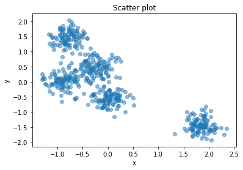

```python
x = data['X']
y = data['Y']
plt.scatter(x, y, alpha=0.5)
plt.title('Scatter plot')
plt.xlabel('x')
plt.ylabel('y')
plt.show()
```

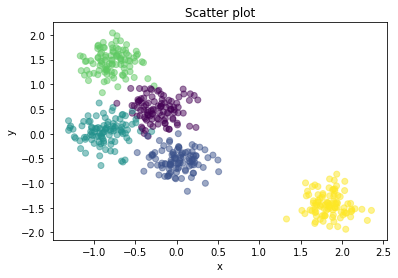

```python
x = data['X']
y = data['Y']
colors = data['Centers']
plt.scatter(x, y, c=colors, alpha=0.5)
plt.title('Scatter plot')
plt.xlabel('x')
plt.ylabel('y')
plt.show()
```

```python
from sklearn.cluster import KMeans
kmeans = KMeans(n_clusters=5, random_state=0, verbose=0)
X = data[['X', 'Y']]
kmeans.fit(X)
```

```
KMeans(algorithm='auto', copy_x=True, init='k-means++', max_iter=300,
       n_clusters=5, n_init=10, n_jobs=None, precompute_distances='auto',
       random_state=0, tol=0.0001, verbose=0)
```

```python
y_kmeans = kmeans.predict(X)
```

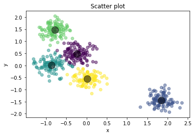

```python
x = data['X']
y = data['Y']
plt.scatter(x, y, c=y_kmeans, alpha=0.5)
centers = kmeans.cluster_centers_
cx = centers[:, 0]
cy = centers[:, 1]
plt.scatter(cx, cy, c='black', s=200, alpha=0.5);
plt.title('Scatter plot')
plt.xlabel('x')
plt.ylabel('y')
plt.show()
```

```python
y_cluster = pd.DataFrame(y_kmeans)
y_cluster.columns = ['Cluster']
y_cluster.reset_index(drop=True, inplace=True)
data.reset_index(drop=True, inplace=True)
data_cluster = pd.concat([data, y_cluster], axis=1)
data_cluster.head()
```

|  | X | Y | Centers | Cluster |
| --- | --- | --- | --- | --- |
| 0 | 0.179475 | -0.887330 | 1.0 | 4 |
| 1 | -0.434891 | 0.476934 | 0.0 | 0 |
| 2 | 0.088348 | 0.805723 | 0.0 | 0 |
| 3 | -0.834877 | 0.185184 | 2.0 | 2 |
| 4 | -0.423814 | 0.135387 | 0.0 | 0 |

```python
a = np.int_(data_cluster['Centers'])
b = data_cluster['Cluster']
cross = pd.crosstab(a, b, rownames=['Centers'], colnames=['Cluster'])
display(cross)
```

| Cluster Centers | 0 | 1 | 2 | 3 | 4 |
| --- | --- | --- | --- | --- | --- |
| 0 | 98 | 0 | 2 | 0 | 0 |
| 1 | 1 | 0 | 1 | 0 | 98 |
| 2 | 5 | 0 | 95 | 0 | 0 |
| 3 | 1 | 0 | 0 | 99 | 0 |
| 4 | 0 | 100 | 0 | 0 | 0 |

Theano is a very powerful library that has been used in large-scale computationally intensive scientific projects for a long time but is simple and approachable enough to be used by individuals for their own projects.

```python
# Python program using Theano
# for computing a Logistic
# Function

import theano
import theano.tensor as T
from theano import function

x = T.dmatrix('x')
y = T.dmatrix('y')
z = x + y
f = function([x, y], z)
foo = f([[1, 2], [3, 4]], [[10, 20], [30, 40]])
print(foo)

x = T.dmatrix('x')
s = 1 / (1 + T.exp(-x))
logistic = theano.function([x], s)
foo = logistic([[0, 1], [-1, -2]])
print(foo)

a = theano.tensor.vector() # declare variable
out = a + a ** 10
f = theano.function([a], out)
foo = f([0, 1, 2])
print(foo)
```

```
[[11. 22.]
 [33. 44.]]
[[0.5        0.73105858]
 [0.26894142 0.11920292]]
[   0.    2. 1026.]
```

```python
# declare variables
x = theano.tensor.fvector('x')
target = theano.tensor.fscalar('target')
W = theano.shared(np.asarray([0.2, 0.7]), 'W')

# create expressions
y = (x * W).sum()
cost = theano.tensor.sqr(target - y)
gradients = theano.tensor.grad(cost, [W])

W_updated = W - (0.1 * gradients[0])
updates = [(W, W_updated)]

# create a callable object from expression
f = theano.function([x, target], y, updates=updates)

# call the function and print results
for i in range(10):
    result = f([1.0, 1.0], 20.0)
    print(result)
```

```
0.8999999999999999
8.540000000000001
13.124
15.874400000000001
17.52464
18.514784000000002
19.1088704
19.46532224
19.679193343999998
19.8075160064
```

TensorFlow is a very popular open-source library for high performance numerical computation developed by the Google Brain team in Google. As the name suggests, Tensorflow is a framework that involves defining and running computations involving tensors. It can train and run deep neural networks that can be used to develop several AI applications. TensorFlow is widely used in the field of deep learning research and application.

```python
#  Python program using TensorFlow
#  for multiplying two arrays

# import tensorflow
import numpy as np
import tensorflow.compat.v1 as tf
tf.disable_v2_behavior()

# Initialize variables
X_1 = tf.placeholder(tf.float32, name = "X_1")
X_2 = tf.placeholder(tf.float32, name = "X_2")

multiply = tf.multiply(X_1, X_2, name = "multiply")

# Initialize the Session
session = tf.Session()

# Print the result
result = session.run(multiply, feed_dict={X_1:[1,2,3], X_2:[4,5,6]})
print(result)

# Close the session
session.close()
```

```
WARNING:tensorflow:From C:\ProgramData\Anaconda3\lib\site-packages\tensorflow_core\python\compat\v2_compat.py:88: disable_resource_variables (from tensorflow.python.ops.variable_scope) is deprecated and will be removed in a future version.
Instructions for updating:
non-resource variables are not supported in the long term
[ 4. 10. 18.]
```

PyTorch is a popular open-source Machine Learning library for Python based on Torch, which is an open-source Machine Learning library which is implemented in C with a wrapper in Lua. It has an extensive choice of tools and libraries that supports on Computer Vision, Natural Language Processing(NLP) and many more ML programs. It allows developers to perform computations on Tensors with GPU acceleration and also helps in creating computational graphs.

```python
# Python program using PyTorch
# for defining tensors fit a
# two-layer network to random
# data and calculating the loss

import torch
import numpy as np

dtype = torch.float
device = torch.device("cpu")
# device = torch.device("cuda:0") Uncomment this to run on GPU

# N is batch size; D_in is input dimension;
# H is hidden dimension; D_out is output dimension.
N, D_in, H, D_out = 64, 1000, 100, 10

# Create random input and output data
x = torch.randn(N, D_in, device = device, dtype = dtype)
y = torch.randn(N, D_out, device = device, dtype = dtype)

# Randomly initialize weights
w1 = torch.randn(D_in, H, device = device, dtype = dtype)
w2 = torch.randn(H, D_out, device = device, dtype = dtype)

learning_rate = 1e-6
for t in range(500):
    # Forward pass: compute predicted y
    h = x.mm(w1)
    h_relu = h.clamp(min = 0)
    y_pred = h_relu.mm(w2)

    # Compute and print loss
    loss = (y_pred - y).pow(2).sum().item()
    if (t%20)==0:
        print(t, loss)

    # Backprop to compute gradients of w1 and w2 with respect to loss
    grad_y_pred = 2.0 * (y_pred - y)
    grad_w2 = h_relu.t().mm(grad_y_pred)
    grad_h_relu = grad_y_pred.mm(w2.t())
    grad_h = grad_h_relu.clone()
    grad_h[h < 0] = 0
    grad_w1 = x.t().mm(grad_h)

    # Update weights using gradient descent
    w1 -= learning_rate * grad_w1
    w2 -= learning_rate * grad_w2
```

```
0 34356648.0
20 273916.5
40 44186.69921875
60 11609.0986328125
80 3777.15234375
100 1386.4691162109375
120 547.611328125
140 227.76930236816406
160 98.28556823730469
180 43.56733703613281
200 19.708160400390625
220 9.057795524597168
240 4.214049339294434
260 1.9796828031539917
280 0.937345027923584
300 0.4466283917427063
320 0.21393834054470062
340 0.10297144949436188
360 0.049778569489717484
380 0.024212412536144257
400 0.011922711506485939
420 0.006013745442032814
440 0.003128121607005596
460 0.0017141647404059768
480 0.0009967321529984474
```

Pandas is a popular Python library for data analysis. It is not directly related to Machine Learning. As we know that the dataset must be prepared before training. In this case, Pandas comes handy as it was developed specifically for data extraction and preparation. It provides high-level data structures and wide variety tools for data analysis. It provides many inbuilt methods for groping, combining and filtering data.

```python
# Python program using Pandas for
# arranging a given set of data
# into a  table

# importing pandas as pd
import pandas as pd
import pickle
from IPython.display import display, Image

data = {"country": ["Brazil", "Russia", "India", "China", "South Africa"],
       "capital": ["Brasilia", "Moscow", "New Dehli", "Beijing", "Pretoria"],
       "area": [8.516, 17.10, 3.286, 9.597, 1.221],
       "population": [200.4, 143.5, 1252, 1357, 52.98] }

data_table = pd.DataFrame(data)
display(data_table)
```

|  | country | capital | area | population |
| --- | --- | --- | --- | --- |
| 0 | Brazil | Brasilia | 8.516 | 200.40 |
| 1 | Russia | Moscow | 17.100 | 143.50 |
| 2 | India | New Dehli | 3.286 | 1252.00 |
| 3 | China | Beijing | 9.597 | 1357.00 |
| 4 | South Africa | Pretoria | 1.221 | 52.98 |

```python
data_table.to_pickle('Pickle.pkl')
```

```python
data_tablep = pd.read_pickle('Pickle.pkl')
display(data_tablep)
```

|  | country | capital | area | population |
| --- | --- | --- | --- | --- |
| 0 | Brazil | Brasilia | 8.516 | 200.40 |
| 1 | Russia | Moscow | 17.100 | 143.50 |
| 2 | India | New Dehli | 3.286 | 1252.00 |
| 3 | China | Beijing | 9.597 | 1357.00 |
| 4 | South Africa | Pretoria | 1.221 | 52.98 |

```python
dbfile = open('Pickle.pkl', 'wb') #write binary
pickle.dump(data_table, dbfile)
dbfile.close()
```

```python
file = open('Pickle.pkl', 'rb')
data_tablep = pickle.load(file)
file.close()
display(data_tablep)
```

|  | country | capital | area | population |
| --- | --- | --- | --- | --- |
| 0 | Brazil | Brasilia | 8.516 | 200.40 |
| 1 | Russia | Moscow | 17.100 | 143.50 |
| 2 | India | New Dehli | 3.286 | 1252.00 |
| 3 | China | Beijing | 9.597 | 1357.00 |
| 4 | South Africa | Pretoria | 1.221 | 52.98 |

```python
table = data_table.iloc[:, 0:2]
display(table)
```

|  | country | capital |
| --- | --- | --- |
| 0 | Brazil | Brasilia |
| 1 | Russia | Moscow |
| 2 | India | New Dehli |
| 3 | China | Beijing |
| 4 | South Africa | Pretoria |

```python
table = data_table[['country','capital']]
display(table)
```

|  | country | capital |
| --- | --- | --- |
| 0 | Brazil | Brasilia |
| 1 | Russia | Moscow |
| 2 | India | New Dehli |
| 3 | China | Beijing |
| 4 | South Africa | Pretoria |

```python
table = data_table.iloc[0:2, :]
display(table)
```

|  | country | capital | area | population |
| --- | --- | --- | --- | --- |
| 0 | Brazil | Brasilia | 8.516 | 200.4 |
| 1 | Russia | Moscow | 17.100 | 143.5 |

```python
population = data_table.loc[data_table['population'] >= 1000]
display(population)
```

|  | country | capital | area | population |
| --- | --- | --- | --- | --- |
| 2 | India | New Dehli | 3.286 | 1252.0 |
| 3 | China | Beijing | 9.597 | 1357.0 |

XGBoost is an optimized distributed gradient boosting library designed to be highly efficient, flexible and portable. It implements machine learning algorithms under the Gradient Boosting framework. XGBoost provides a parallel tree boosting (also known as GBDT, GBM) that solve many data science problems in a fast and accurate way.

```python
import numpy as np
import pandas as pd
import seaborn as sns
from IPython.display import display, Image
```

```python
iris = sns.load_dataset("iris")
iris.head()
```

|  | sepal_length | sepal_width | petal_length | petal_width | species |
| --- | --- | --- | --- | --- | --- |
| 0 | 5.1 | 3.5 | 1.4 | 0.2 | setosa |
| 1 | 4.9 | 3.0 | 1.4 | 0.2 | setosa |
| 2 | 4.7 | 3.2 | 1.3 | 0.2 | setosa |
| 3 | 4.6 | 3.1 | 1.5 | 0.2 | setosa |
| 4 | 5.0 | 3.6 | 1.4 | 0.2 | setosa |

```python
from xgboost import XGBClassifier
from sklearn.model_selection import train_test_split
from sklearn.metrics import accuracy_score
```

```python
# split data into X and y
X = iris.iloc[:,0:3]
Y = iris.iloc[:,4]
```

```python
# split data into train and test sets
seed = 7
test_size = 0.33
X_train, X_test, y_train, y_test = train_test_split(X, Y, test_size=test_size, random_state=seed)
```

```python
# fit model no training data
model = XGBClassifier()
model.fit(X_train, y_train)
```

```
XGBClassifier(base_score=0.5, booster='gbtree', colsample_bylevel=1,
              colsample_bynode=1, colsample_bytree=1, gamma=0,
              learning_rate=0.1, max_delta_step=0, max_depth=3,
              min_child_weight=1, missing=None, n_estimators=100, n_jobs=1,
              nthread=None, objective='multi:softprob', random_state=0,
              reg_alpha=0, reg_lambda=1, scale_pos_weight=1, seed=None,
              silent=None, subsample=1, verbosity=1)
```

```python
print(model)
```

```
XGBClassifier(base_score=0.5, booster='gbtree', colsample_bylevel=1,
              colsample_bynode=1, colsample_bytree=1, gamma=0,
              learning_rate=0.1, max_delta_step=0, max_depth=3,
              min_child_weight=1, missing=None, n_estimators=100, n_jobs=1,
              nthread=None, objective='multi:softprob', random_state=0,
              reg_alpha=0, reg_lambda=1, scale_pos_weight=1, seed=None,
              silent=None, subsample=1, verbosity=1)
```

```python
# make predictions for test data
predictions = model.predict(X_test)
```

```python
# evaluate predictions
accuracy = accuracy_score(y_test, predictions)
print("Accuracy: %.2f%%" % (accuracy * 100.0))
```

```
Accuracy: 88.00%
```